# Estimating Loss in the 15th-c. Vernacular Song Repertoire

This notebook uses the functionality in the `iceberg` package to estimate survival rates for literate song across various languages in fifteenth-century Europe. The capta are sourced from the alpha version of [the Digital Index of Late Medieval Song (DILMS)](https://www.dilms.org).

```python
import numpy as np
import pandas as pd

import matplotlib.pyplot as plt
import seaborn as sns
sns.set_theme(
    context='notebook',
    style='darkgrid',
    palette='mako',
)

import iceberg.estimate as est
```

The capta in question are fairly simple, just pairs of `SongName` and `SourceName` for several linguistic buckets (these became `song_name` and `source_name` in later releases of DILMS). A sample of the captaset for all languages is shown below; for more details about the delicate and fraught nature of language in DILMS see that project's documentation.

```python
# Sample of all-language captaset
pd.read_csv('../../DILMS Captasets/all_15c.csv').head(8)
```

|  | SongName | SourceName |
| --- | --- | --- |
| 0 | Herte myne well may thou be | Strasbourg Index |
| 1 | Tappster dryngker fyll another ale annon | Selden Carol Book |
| 2 | So ys emprentid in my remembrance | Berlin Chansonnier |
| 3 | So ys emprentid in my remembrance | Escorial B |
| 4 | So ys emprentid in my remembrance | Florence 176 |
| 5 | So ys emprentid in my remembrance | Ascoli Piceno Fragment |
| 6 | So ys emprentid in my remembrance | Laborde Chansonnier !1 |
| 7 | So ys emprentid in my remembrance | Montecassino 871 |

Let's import all of the linguistically-segmented captasets, estimate survival rates using 256 cross-validation experiments, and plot.

```python
# Prep
languages = ['all', 'english', 'french', 'german', 'italian']
estimates = {
    'Language': [],
    'extant': [],
    'estimate': []
}

# Process capta
for language in languages:
    capta = pd.read_csv('../../DILMS Captasets/' + language + '_15c.csv')
    pairs = capta.values.tolist()
    source_d= {}
    songs = set()
    for pair in pairs:
        songs.add(pair[0])
        if pair[1] not in source_d:
            source_d[pair[1]] = [pair[0]]
        else:
            source_d[pair[1]].append(pair[0])
    sources = list(source_d.values())
    np.random.seed(1729)
    ice = est.cuthbert(sources, cv=256)
    for i in range(len(ice['corrected'])):
        estimates['Language'].append(language.capitalize())
        estimates['extant'].append(len(songs))
        estimates['estimate'].append(ice['corrected'][i])

estimates = pd.DataFrame(estimates)
```

```python
# Inspect result
estimates.head()
```

|  | Language | extant | estimate |
| --- | --- | --- | --- |
| 0 | All | 2185 | 2617 |
| 1 | All | 2185 | 2661 |
| 2 | All | 2185 | 2596 |
| 3 | All | 2185 | 2731 |
| 4 | All | 2185 | 2645 |

```python
# Add column indicating the estimated survival rate
estimates['est_p'] = estimates['extant'] / estimates['estimate']
estimates.head()
```

|  | Language | extant | estimate | est_p |
| --- | --- | --- | --- | --- |
| 0 | All | 2185 | 2617 | 0.834925 |
| 1 | All | 2185 | 2661 | 0.821120 |
| 2 | All | 2185 | 2596 | 0.841680 |
| 3 | All | 2185 | 2731 | 0.800073 |
| 4 | All | 2185 | 2645 | 0.826087 |

```python
# Inspect aggregate results
estimates.groupby('Language').mean().reset_index()
```

|  | Language | extant | estimate | est_p |
| --- | --- | --- | --- | --- |
| 0 | All | 2185.0 | 2728.371094 | 0.801362 |
| 1 | English | 47.0 | 158.523438 | 0.303094 |
| 2 | French | 1347.0 | 1607.660156 | 0.838306 |
| 3 | German | 329.0 | 476.304688 | 0.698782 |
| 4 | Italian | 215.0 | 347.675781 | 0.620876 |

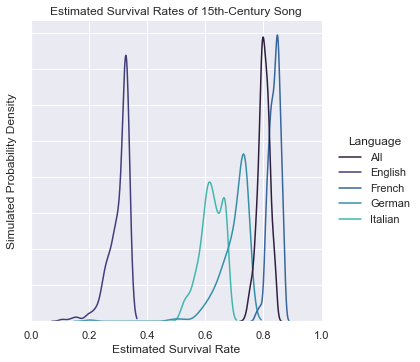

```python
# Plot the distributions for a finer-grained look
plt.rcParams['figure.figsize'] = [12, 8]

p_plot = sns.displot(
    estimates,
    x='est_p',
    hue='Language',
    kind='kde',
)

plt.xlim(0, 1)

p_plot.set(
    title='Estimated Survival Rates of 15th-Century Song',
    xlabel='Estimated Survival Rate',
    ylabel='Simulated Probability Density',
    yticklabels=[]
)

plt.show();
```